# Analyzing the WeRateDogs twitter handle

```python
#imports
import numpy as np
import pandas as pd
import requests
import io
import tweepy
import json
import os
import time
import re
import matplotlib.pyplot as plt
import seaborn as sns
%matplotlib inline
sns.set_style('darkgrid' )
```

```python
# For the purpose of analysis I created a DataFrame Copy as dfc
df=pd.read_csv('twitter_archive_master.csv')
```

```python
df.head()
```

|  | tweet_id | timestamp | source | url | jpg_url | is_reply | text | name | rating_numerator | breed_fin | stage | floofer | favorite_count | retweet_count |
| --- | --- | --- | --- | --- | --- | --- | --- | --- | --- | --- | --- | --- | --- | --- |
| 0 | 892420643555336193 | 2017-08-01 16:23:56 | Twitter for iPhone | https://twitter.com/dog_rates/status/892420643... | https://pbs.twimg.com/media/DGKD1-bXoAAIAUK.jpg | 0 | This is Phineas. He's a mystical boy. Only eve... | Phineas | 13.0 | NaN | NaN | 0 | 38689 | 8558 |
| 1 | 892177421306343426 | 2017-08-01 00:17:27 | Twitter for iPhone | https://twitter.com/dog_rates/status/892177421... | https://pbs.twimg.com/media/DGGmoV4XsAAUL6n.jpg | 0 | This is Tilly. She's just checking pup on you.... | Tilly | 13.0 | Chihuahua | NaN | 0 | 33164 | 6292 |
| 2 | 891815181378084864 | 2017-07-31 00:18:03 | Twitter for iPhone | https://twitter.com/dog_rates/status/891815181... | https://pbs.twimg.com/media/DGBdLU1WsAANxJ9.jpg | 0 | This is Archie. He is a rare Norwegian Pouncin... | Archie | 12.0 | Chihuahua | NaN | 0 | 24966 | 4174 |
| 3 | 891689557279858688 | 2017-07-30 15:58:51 | Twitter for iPhone | https://twitter.com/dog_rates/status/891689557... | https://pbs.twimg.com/media/DF_q7IAWsAEuuN8.jpg | 0 | This is Darla. She commenced a snooze mid meal... | Darla | 13.0 | Labrador Retriever | NaN | 0 | 42074 | 8689 |
| 4 | 891327558926688256 | 2017-07-29 16:00:24 | Twitter for iPhone | https://twitter.com/dog_rates/status/891327558... | https://pbs.twimg.com/media/DF6hr6BUMAAzZgT.jpg | 0 | This is Franklin. He would like you to stop ca... | Franklin | 12.0 | Basset | NaN | 0 | 40227 | 9451 |

```python
df.info()
```

```
<class 'pandas.core.frame.DataFrame'>
RangeIndex: 2124 entries, 0 to 2123
Data columns (total 14 columns):
tweet_id            2124 non-null int64
timestamp           2124 non-null object
source              2124 non-null object
url                 2124 non-null object
jpg_url             1953 non-null object
is_reply            2124 non-null int64
text                2124 non-null object
name                2123 non-null object
rating_numerator    2124 non-null float64
breed_fin           1673 non-null object
stage               334 non-null object
floofer             2124 non-null int64
favorite_count      2124 non-null int64
retweet_count       2124 non-null int64
dtypes: float64(1), int64(5), object(8)
memory usage: 232.4+ KB
```

### Insight #1: Descriptive stats

```python
df[['rating_numerator', 'favorite_count', 'retweet_count']].describe()
```

|  | rating_numerator | favorite_count | retweet_count |
| --- | --- | --- | --- |
| count | 2124.000000 | 2124.000000 | 2124.000000 |
| mean | 10.775085 | 8761.723635 | 2718.199623 |
| std | 1.891892 | 12417.271299 | 4669.526492 |
| min | 4.000000 | 51.000000 | 0.000000 |
| 25% | 10.000000 | 1908.750000 | 591.750000 |
| 50% | 11.000000 | 4027.000000 | 1307.000000 |
| 75% | 12.000000 | 11017.000000 | 3130.000000 |
| max | 15.000000 | 142995.000000 | 77131.000000 |

```python
df['rating_numerator'].mode()
```

```
0    12.0
dtype: float64
```

These descriptive stats seem pretty boring but they give us some useful insights to our data. Lets analyze them:

##### rating_numerator

- lets look at values of central measure:
  - mean: 10.78
  - median: 11
  - mode: 12
- we see that mean<median<mode
- inference: distribution of rating_numerator should be left skewed

##### favorite_count

Let us now seee if our inference is correct

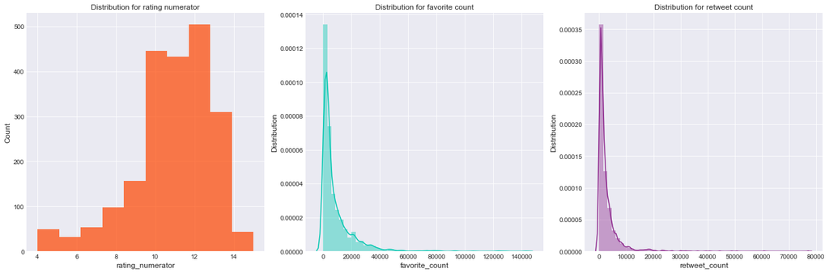

```python
plt.figure(figsize=(18,6))

plt.subplot(1, 3, 1)
df.rating_numerator.hist(color= (1,0.27,0), alpha=.7)
plt.ylabel('Count', fontsize=12)
plt.xlabel('rating_numerator', fontsize=12)
plt.title('Distribution for rating numerator')

plt.subplot(1, 3, 2)
sns.distplot(df.favorite_count, color= (0,.78,.69));
plt.ylabel('Distribution', fontsize=12)
plt.xlabel('favorite_count', fontsize=12)
plt.title('Distribution for favorite count')

plt.subplot(1, 3, 3)
sns.distplot(df.retweet_count, color= (0.55,0.15,0.55))
plt.ylabel('Distribution', fontsize=12)
plt.xlabel('retweet_count', fontsize=12)
plt.title('Distribution for retweet count')

plt.tight_layout();
```

It looks like our inference was correct. The rating_numerator is skewed to the left while favourite_count and retweet_count are skewed to the right.

Conclusion: Most dogs are likely to get a higher rating but more dogs are likely to get low retweet count and favorite count. This conclusion can be attributed to who controls the these values and how it affects them.

The user of WeRateDogs twitter handle doesn't lose much from giving higher ratings, actually it makes the rating system more unique. While followers control the retweet count. Retweeting or favorating a post takes valuable time out of their life, just like a company doesn't give high salary to most employees, followers dont give high retweet and favorite counts to most dogs.

### Insight #2: Change in average ratings with time

From above analysis I feel there is a possibility that the ratings have actually increased with time. But I would like to check my assumption using the data I have wrangled with so much effort.

In order to do so I will now group the data by month and year while taking the mean to see if my assumption is right. This is done to reduce noise and can be useful later.

```python
# Creating a new column for year and month
df['year_month']=df['timestamp'].values.astype('datetime64[M]')
```

```python
df_grouped_mean = df.groupby('year_month').mean().reset_index()[['year_month', 'rating_numerator', 'favorite_count', 'retweet_count']]
```

```python
df_grouped_mean
```

|  | year_month | rating_numerator | favorite_count | retweet_count |
| --- | --- | --- | --- | --- |
| 0 | 2015-11-01 | 9.303887 | 1116.448763 | 469.084806 |
| 1 | 2015-12-01 | 9.863723 | 3484.207447 | 1495.279255 |
| 2 | 2016-01-01 | 10.343915 | 3856.243386 | 1482.455026 |
| 3 | 2016-02-01 | 10.219512 | 4103.650407 | 1516.902439 |
| 4 | 2016-03-01 | 10.671642 | 4519.328358 | 1687.723881 |
| 5 | 2016-04-01 | 10.827586 | 4612.189655 | 1590.586207 |
| 6 | 2016-05-01 | 10.916667 | 6091.633333 | 2167.650000 |
| 7 | 2016-06-01 | 10.489130 | 8818.826087 | 3838.695652 |
| 8 | 2016-07-01 | 10.895833 | 7405.479167 | 2762.833333 |
| 9 | 2016-08-01 | 11.015873 | 9779.428571 | 3399.841270 |
| 10 | 2016-09-01 | 11.371618 | 10881.955882 | 3513.647059 |
| 11 | 2016-10-01 | 11.750000 | 13505.479452 | 4482.849315 |
| 12 | 2016-11-01 | 11.965517 | 13434.965517 | 4362.000000 |
| 13 | 2016-12-01 | 11.948276 | 16287.068966 | 5483.206897 |
| 14 | 2017-01-01 | 12.281690 | 18315.352113 | 5852.774648 |
| 15 | 2017-02-01 | 12.231884 | 17220.985507 | 4033.869565 |
| 16 | 2017-03-01 | 12.375000 | 19136.339286 | 4505.160714 |
| 17 | 2017-04-01 | 12.319149 | 21007.957447 | 5107.276596 |
| 18 | 2017-05-01 | 12.777778 | 28567.688889 | 7326.933333 |
| 19 | 2017-06-01 | 12.560000 | 27349.200000 | 6116.780000 |
| 20 | 2017-07-01 | 12.820755 | 31152.660377 | 6733.075472 |
| 21 | 2017-08-01 | 13.000000 | 35926.500000 | 7425.000000 |

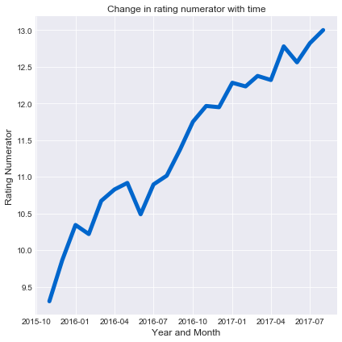

```python
plt.figure(figsize=(6,6))
plt.plot(df_grouped_mean.year_month, df_grouped_mean.rating_numerator, linewidth= 5,color= (0,.4,.8))
plt.ylabel('Rating Numerator', fontsize=12)
plt.xlabel('Year and Month', fontsize=12)
plt.title('Change in rating numerator with time')

plt.tight_layout();
```

It seems like with time dogs are getting cuter. Oh wait!! Dogs have always been and always will be cute, but WeRateDogs surely seems to be increasing the average ratings with time.

### Insight #3: Adjusted ratings

This makes me wonder, is this the reason that our rating_numerator distribution was negatively (left) skewed? What about a dog with a rating 9 in November 2015? Is that dog a 12 if I adjust for the dog rating inflation? How about we test this with our data.

Maybe we should have a subject in college called Doggonomics, I surely would take that class even if it is just trying to teach us the basics behind normalizing and inflation.

In order to do this analysis we need to divide the ratings by the mean rating of that month and then multiple it by the current average.

```python
df_adjusted=df.merge(df_grouped_mean, how= 'left', on='year_month', validate= 'm:1')
```

```python
df_adjusted['adjusted_numerator']=  df_adjusted.rating_numerator_y.iloc[0]* df_adjusted.rating_numerator_x/df_adjusted.rating_numerator_y
```

```python
df_adjusted[['adjusted_numerator', 'rating_numerator_x']].iloc[np.r_[0:5, -10:0]]
```

|  | adjusted_numerator | rating_numerator_x |
| --- | --- | --- |
| 0 | 13.000000 | 13.0 |
| 1 | 13.000000 | 13.0 |
| 2 | 12.167770 | 12.0 |
| 3 | 13.181751 | 13.0 |
| 4 | 12.167770 | 12.0 |
| 2114 | 13.972655 | 10.0 |
| 2115 | 11.178124 | 8.0 |
| 2116 | 12.575389 | 9.0 |
| 2117 | 13.972655 | 10.0 |
| 2118 | 13.972655 | 10.0 |
| 2119 | 6.986327 | 5.0 |
| 2120 | 8.383593 | 6.0 |
| 2121 | 12.575389 | 9.0 |
| 2122 | 9.780858 | 7.0 |
| 2123 | 11.178124 | 8.0 |

Seems like back in the day a 9 was almost equivalent to today's 12.5, this could bring a big smile to dog owners that got the ratings initially and ofcourse all those puppers and puppos that are now good doggos. Hope "Bront" doesn't see this analysis.

Lets see if our distribution changed.

```python
df_adjusted.adjusted_numerator.mode(), df_adjusted.adjusted_numerator.describe()
```

```
(0    13.179607
 dtype: float64, count    2124.000000
 mean       13.000000
 std         1.992223
 min         4.720461
 25%        12.169602
 50%        13.179607
 75%        14.144300
 max        18.164451
 Name: adjusted_numerator, dtype: float64)
```

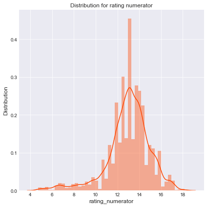

```python
plt.figure(figsize=(6,6))
sns.distplot(df_adjusted.adjusted_numerator, color= (1,0.27,0))
plt.ylabel('Distribution', fontsize=12)
plt.xlabel('rating_numerator', fontsize=12)
plt.title('Distribution for rating numerator')
plt.tight_layout();
```

Oh look our distribution definitely looks more normal and less skewed. And all the doggos are probably happier too. Did you notice the measures of central tendencies?

mean<median=mode and this explains the slight skew since the difference between mean and median isn't much.

### Insight #4: Correlations

I also wanted to see if popularity has increased with the increase in the ratings. The correlation will show us how these parameters are related to each other but we still cannot make definite statements about the cause.

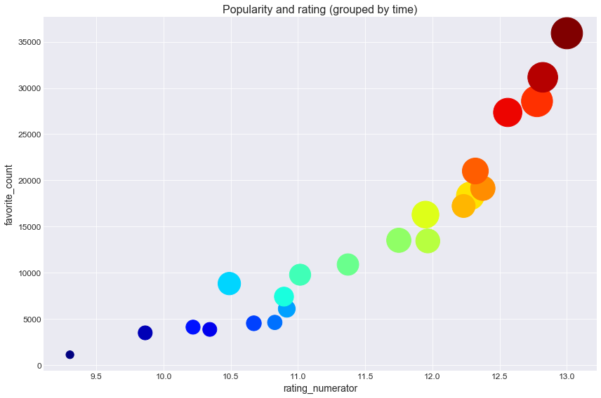

```python
plt.figure(figsize=(12,8))
plt.scatter(x=df_grouped_mean['rating_numerator'], y= df_grouped_mean['favorite_count'], alpha =1, s=2000*df_grouped_mean.retweet_count/(df_grouped_mean.retweet_count.max()), cmap='jet', c=df_grouped_mean['year_month'])
plt.xticks(fontsize=12)
plt.yticks(fontsize=12)
plt.ylabel('favorite_count', fontsize=14)
plt.xlabel('rating_numerator', fontsize=14)
plt.title('Popularity and rating (grouped by time)',fontsize=16)
plt.tight_layout();
```

In the plot above the x-axis has the rating numerator, the y-axis has the favorite count, the size of bubbles represent the retweet_count and the color transition shows the change in time with blue being the oldest and red being the most recent

```python
rating_corr_fav_grp= df_grouped_mean.rating_numerator.corr(df_grouped_mean.favorite_count)
rating_corr_rtwt_grp= df_grouped_mean.rating_numerator.corr(df_grouped_mean.retweet_count)

print ('Correlation between rating_numerator and favorite_count when grouped by month:{}'.format(rating_corr_fav_grp))
print ('Correlation between rating_numerator and retweet_count when grouped by month:{}'.format(rating_corr_rtwt_grp))
```

```
Correlation between rating_numerator and favorite_count when grouped by month:0.9283792203543333
Correlation between rating_numerator and retweet_count when grouped by month:0.9323215285988581
```

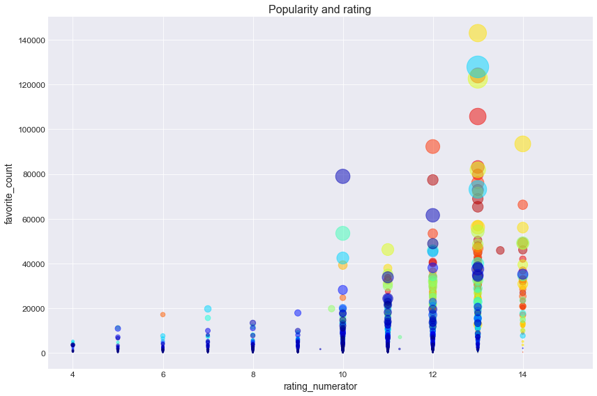

```python
plt.figure(figsize=(12,8))
plt.scatter(x=df['rating_numerator'], y= df['favorite_count'], alpha =.5, s=50*df.retweet_count/(df_grouped_mean.retweet_count.median()), cmap='jet', c=df['year_month'])
plt.xticks(fontsize=12)
plt.yticks(fontsize=12)
plt.ylabel('favorite_count', fontsize=14)
plt.xlabel('rating_numerator', fontsize=14)
plt.title('Popularity and rating',fontsize=16)
plt.tight_layout();
```

In the plot above the x-axis has the rating numerator, the y-axis has the favorite count, the size of bubbles represent the retweet_count and the color transition shows the change in time with blue being the oldest and red being the most recent

```python
rating_corr_fav= df.rating_numerator.corr(df.favorite_count)
rating_corr_rtwt= df.rating_numerator.corr(df.retweet_count)

print ('Correlation between rating_numerator and favorite_count when grouped by month:{}'.format(rating_corr_fav))
print ('Correlation between rating_numerator and retweet_count when grouped by month:{}'.format(rating_corr_rtwt))
```

```
Correlation between rating_numerator and favorite_count when grouped by month:0.41708022505371967
Correlation between rating_numerator and retweet_count when grouped by month:0.3203817930361582
```

Here you can a strong correlation between rating numerator and popularity when data is grouped monthly (note: this doesnt show the direct correlation but one that is based on grouped mean) ie mean favorite_count and mean retweet_count increase with the increase in mean rating_numerator over time

But the direct correlations do not show strong relationships

### Insight #4: Popularity by breeds visualization

I forgot that we had some data about breeds too. Maybe we should see what this information tells us.

For this I am going to group the data by breed_fin column

```python
df_breed= df[['breed_fin','rating_numerator', 'favorite_count', 'retweet_count']].groupby('breed_fin').mean()
df_breed= df_breed.sort_values('rating_numerator', ascending=False)
df_breed= df_breed.iloc[:-1,] #this seemed to be an outlier skewing the graph uneccessarily
```

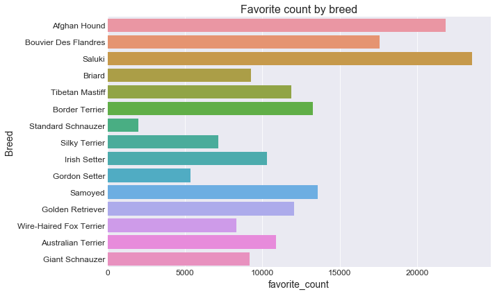

```python
plt.figure(figsize=(10,6))
sns.barplot(y=df_breed.index[:15],x=df_breed.favorite_count[:15])
plt.xticks(fontsize=12)
plt.yticks(fontsize=12)
plt.ylabel('Breed', fontsize=14)
plt.xlabel('favorite_count', fontsize=14)
plt.title('Favorite count by breed',fontsize=16)
plt.tight_layout();
```

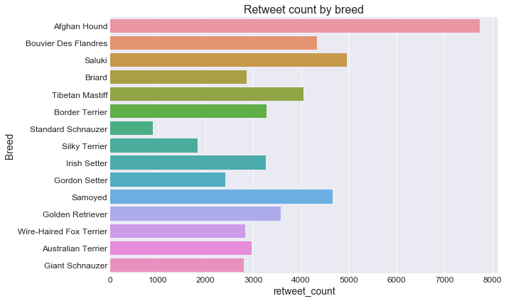

```python
plt.figure(figsize=(10,6))
sns.barplot(y=df_breed.index[:15],x=df_breed.retweet_count[:15])
plt.xticks(fontsize=12)
plt.yticks(fontsize=12)
plt.ylabel('Breed', fontsize=14)
plt.xlabel('retweet_count', fontsize=14)
plt.title('Retweet count by breed',fontsize=16)
plt.tight_layout();
```

There you go. You can see the favorite count and retweet count for the 15 top rated breeds.

## Result Summary

From the above analysis we saw the following:

1. Descriptive stats
   - We see that the graph of rating numerator is left skewed while favorite count and retweet count are right skewed
2. Average rating over time
   - Average ratings have changed increased over time indicating transition to a less strict rating system
3. Adjusted rating
   - Used the average rating over time to normalize the ratings and adjust them to recent rating strictness
4. Correlations
   - When grouped by time, increase in mean ratings is strogly correlated with increase in mean popularity
5. Popularity by breeds
   - Visualized the popularity, ie the favorite count and retweet count of 15 highest rated breeds. Afghan Hound, Bouvier Des Flandres and Saluki were amongst the most popular breeds

## Conclusion

This project was an amazing opportunity to learn and apply data wrangling/cleansing. A clean data is easy to analyze and the analysis made is more accurate. It also allows proper visual representation of the analysis. The use of different python libraries was definitely a good learning experience, I personally enjoyed learning about tweepy library that is used to access the REST API of twitter.